# Accidentalidad vehicular de Medellín por comunas con Modelos Mixtos

Juan Felipe Múnera Vergara

3/21/2020

# Carga de librerias

```r
## Manejo de bases de datos
library(dplyr)
library(magrittr)
## Gráficos
library(ggplot2)
library(lubridate)
## Ajuste de modelos mixtos
library(lme4)
library(brms)
## Manejo de fechas
library("zoo")
## Tablas latex
library(kableExtra)
```

# Objetivo

Construir un modelo predictivo para el numero de accidentes del área Metropolitana de la ciudad de Medellín a nivel barrial/comunal en intervalos mensuales por medio de modelos multinivel, utilizando librerias de R.

# Conjunto de datos:

Los datos se obtienen de la [página](https://geomedellin-m-medellin.opendata.arcgis.com/search?tags=movilidad) del portal [GeoMedellín](https://www.medellin.gov.co/geomedellin/) de la alcaldía de Medellín en su sección de datos abiertos, corresponde a las bases de “Accidentalidad georreferenciada” entre los años 2014 y 2019. Cada elemento del conjunto de datos representa un accidente registrado por la Secretaria de Movilidad de la Alcaldia de Medellín. Para el ajuste de los modelos se descartaron algunas de las covariables (no interesantes para el modelo) y se realizaron cambios al formato de los datos (los cuales pueden ser consultados en detalle [aqui](https://geomedellin-m-medellin.opendata.arcgis.com/search?tags=movilidad)). En general se limitó el estudio a las 16 comunas del área metropolitana de Medellín, (descartandose aquellos accidentes ocurridos en corregimientos) y se agruparon los registros por dichas comunas en periodos mensuales para obtener la cantidad de accidentes por cada clase.

```r
data_men_all <- read.csv("Datasets/base_mensual_barrios_y_comunas.csv", encoding='UTF-8')

#data_men_all %<>%  filter(!(BARRIO == "Inst"))

data_men_all[,c(2,3,4)] %<>% lapply(function(x) factor(as.character(x)))

data_men_all$FECHA <- paste(data_men_all$PERIODO, data_men_all$MES, 1, sep="-") %>% ymd() %>% as.Date()

data_men_all$FECHA <- paste(data_men_all$PERIODO, data_men_all$MES, sep="-") %>% as.yearmon("%Y-%m")

# Para obtener la inversa se usaría: zoo::as.Date(data_men_all$FECHA, origin="2014-01-01")
data_men_all$t <- as.numeric(as.Date(data_men_all$FECHA, frac=0.5)) - as.numeric(as.Date("2014-01-01")) #la primera fecha será 0

data_men_all$MES <- factor(months(data_men_all$FECHA), levels =month.name[1:12])



data_men_comunas <- data_men_all %>% group_by(COMUNA, PERIODO, MES,FECHA, t) %>%
  summarise(nro.accidentes = sum(nro.accidentes),
            Atropello = sum(Atropello),
            Caida.Ocupante = sum(Caida.Ocupante),
            Choque=sum(Choque),
            Volcamiento = sum(Volcamiento),
            Otro = sum(Otro))


## Organización de bases de datos en formato apto para gráficar.


tidy_data_men_all <- tidyr::gather(data_men_all, "CLASE", "nro.accidentes", 5:9)

tidy_data_men_all_comunas <- tidy_data_men_all%>% group_by(COMUNA, t, CLASE) %>%
  summarise(nro.accidentes = sum(nro.accidentes))

## Param brms
data_men_comunas$Accidentalidad <- with(data_men_comunas, cbind(Atropello, Caida.Ocupante, Choque, Volcamiento, Otro))
```

# Análisis descriptivo

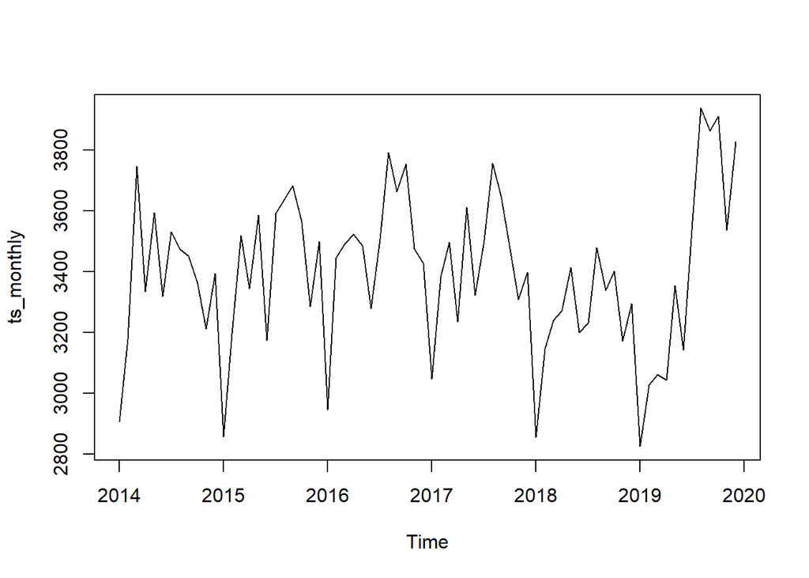

```r
temp <- data_men_comunas %>% group_by(FECHA) %>%
  summarise(nro.accidentes = sum(nro.accidentes))
ts_monthly <- ts(temp$nro.accidentes, start=c(2014,1),frequency=12)
plot(ts_monthly)
```

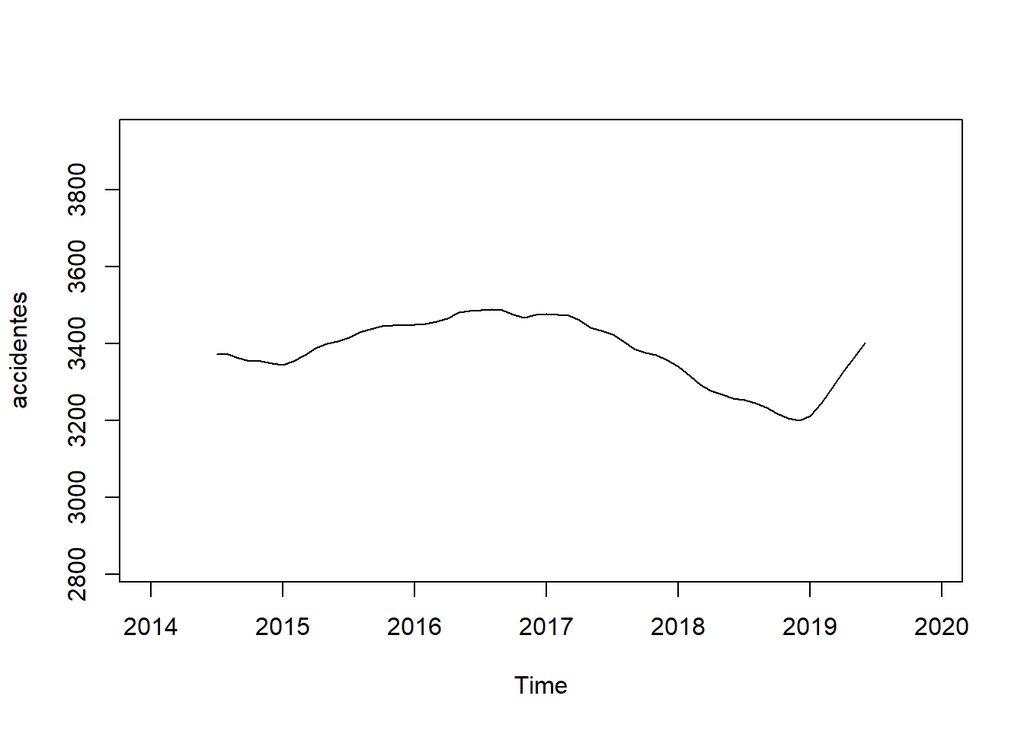

```r
plot(decompose(ts_monthly)$trend,ylim=c(min(ts_monthly),max(ts_monthly)), ylab = "accidentes")
```

```r
temp <- data_men_comunas %>% group_by(COMUNA) %>%
  summarise(nro.accidentes = sum(nro.accidentes),
            Atropello = sum(Atropello),
            Caida.Ocupante = sum(Caida.Ocupante),
            Choque=sum(Choque),
            Volcamiento = sum(Volcamiento),
            Otro = sum(Otro))


temp[order(temp$nro.accidentes, decreasing=T),] %>% kable(align = "c",full_width = F, booktabs = T)%>%
  kable_styling(bootstrap_options = c("striped", "condensed"))
```

| COMUNA | nro.accidentes | Atropello | Caida.Ocupante | Choque | Volcamiento | Otro |
| --- | --- | --- | --- | --- | --- | --- |
| La Candelaria | 52792 | 5120 | 3171 | 39342 | 1253 | 3906 |
| Laureles Estadio | 28385 | 1733 | 1915 | 21407 | 708 | 2622 |
| Castilla | 25359 | 1875 | 2619 | 16757 | 919 | 3189 |
| El Poblado | 20865 | 707 | 952 | 17240 | 532 | 1434 |
| Guayabal | 18343 | 1151 | 1205 | 13618 | 632 | 1737 |
| Belén | 16608 | 1243 | 1221 | 11862 | 585 | 1697 |
| Robledo | 16550 | 1382 | 2466 | 9551 | 621 | 2530 |
| Aranjuez | 14975 | 2038 | 1485 | 9143 | 538 | 1771 |
| Buenos Aires | 9554 | 1017 | 911 | 5907 | 465 | 1254 |
| La América | 8243 | 683 | 701 | 5790 | 221 | 848 |
| Manrique | 7791 | 1641 | 964 | 3762 | 360 | 1064 |
| Doce de Octubre | 6951 | 1355 | 1325 | 2890 | 247 | 1134 |
| Villa Hermosa | 6688 | 1096 | 792 | 3602 | 314 | 884 |
| San Javier | 4435 | 757 | 606 | 2223 | 214 | 635 |
| Popular | 3662 | 1074 | 489 | 1450 | 155 | 494 |
| Santa Cruz | 3393 | 802 | 366 | 1687 | 125 | 413 |

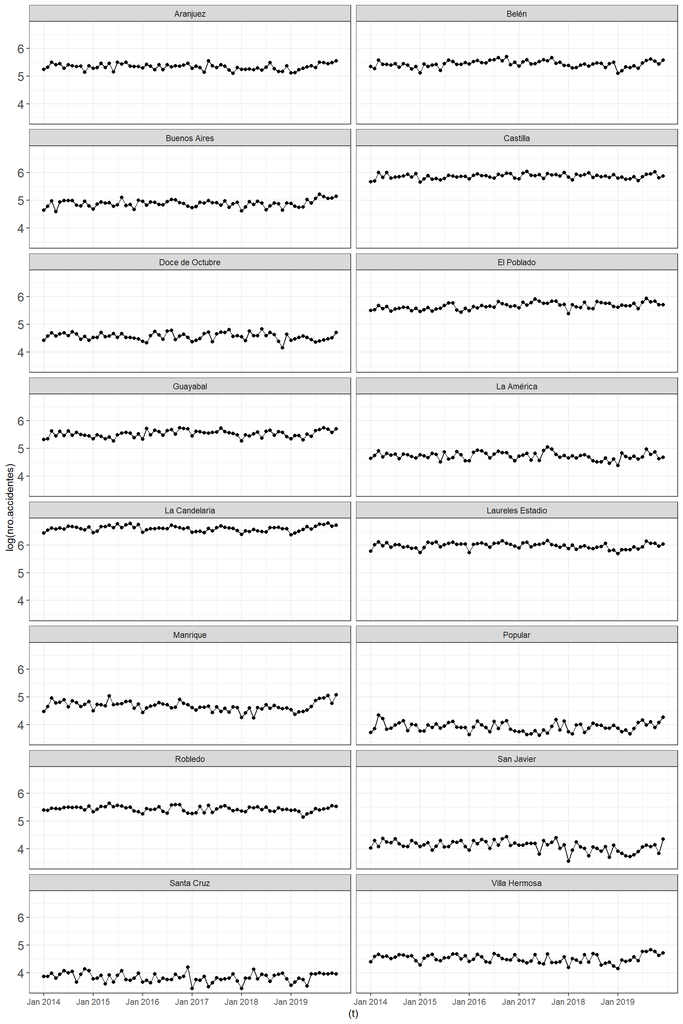

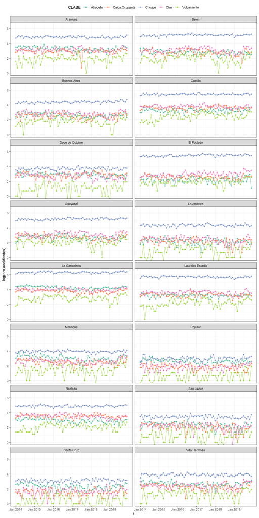

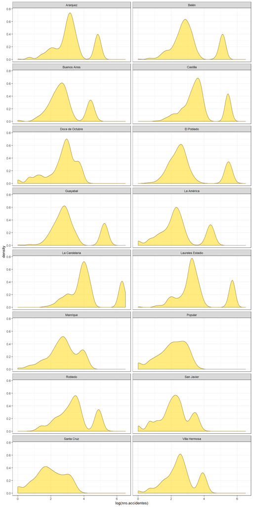

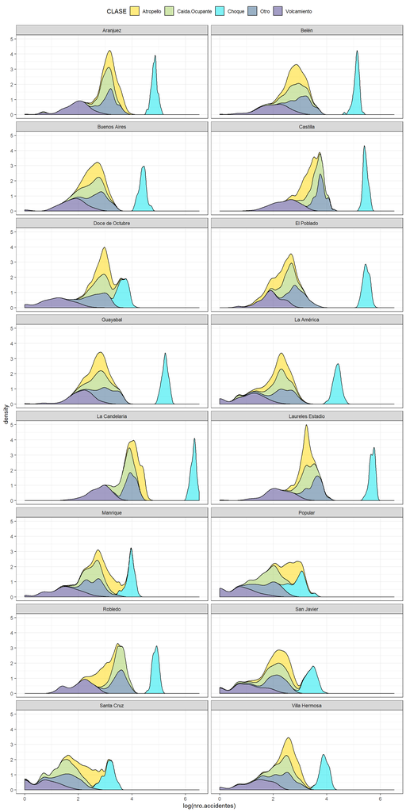

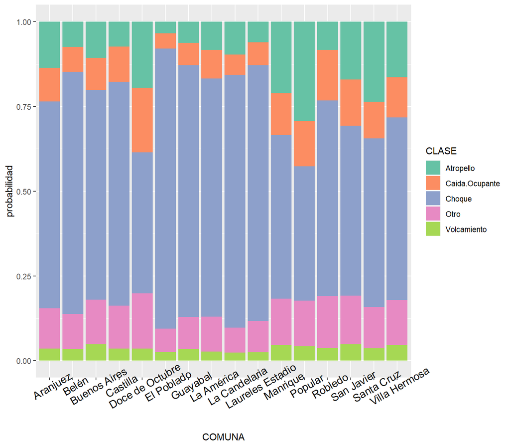

# Modelación y Ajuste

## Modelo con respuesta Poisson

Se quiere modelar el numero de accidentes $n_{ij}$ por medio de una regresión Poisson utilizando

$$n_{ij} \sim Poisson(\lambda_{ij})$$
Se quiere modelar $\lambda_{ij}$

### Modelos propuestos

Con base al análisis descriptivo, se tiene que la tendencia general del modelo tiene que ser modelada a través de un polinomia de alto grado para captar sus cambios de tendencia (inicialmente se considera grado 3). Además, dado que realmente no se notaron tendencias marcadas respecto al numero de accidentes según la comuna, por lo que se descartan modelos con pendiente aleatoria y se restringe a modelo con intercepto aleatorio.

Denotesé:

$$j: Comuna\; (1:16) \\ i: observación\; correspondiente\; a\; un\;mes \; entre \; 2014 \; y \; 2019 \; (1:72)$$
Adicionalmente se notó una periodicidad anual marcada de los meses, por lo que para modelarla la variable MES será incluida en los modelos y será expresada como:
$$\sum\limits_{k=1}^{11}{\delta_{k}}MES_{ijk}\;\; donde\;\; MES_{ik} = \left\{ \begin{matrix} 1 \quad si ~ la ~observación ~ij~ está~ en~la~ estación~k \\ 0 \quad~ otro~caso\end{matrix} \right\}$$

$$k = 1: Febrero, ~ k=2: Marzo, ..., k=10: Noviembre, ~ k=11: Diciembre$$

#### Modelo 1

Polinomio de grado 3 en función del tiempo, con estacionalidad según el MEs e intercepto aleatorio:

$$\log (\lambda_{ij}) = \beta_0 + \beta_1 t + \beta_2t^2 + \beta_3t^3+\sum\limits_{k=1}^{11}{\delta_{k}}MES_{ijk} + b_{0j}$$
$$b_{0j} \sim N(0, \sigma_{b0})$$

#### Modelo 2

Polinomio de grado 4 en función del tiempo, con estacionalidad según el MEs e intercepto aleatorio:

$$\log (\lambda_{ij}) = \beta_0 + \beta_1 t + \beta_2t^2 + \beta_3 t^3+ \beta_4 t^4 +\sum\limits_{k=1}^{11}{\delta_{k}}MES_{ijk} + b_{0j}$$
$$b_{0j} \sim N(0, \sigma_{b0})$$

#### Modelo 3

Polinomio de grado 5 en función del tiempo, con estacionalidad según el MEs e intercepto aleatorio:

$$\log (\lambda_{ij}) = \beta_0 + \beta_1 t + \beta_2t^2 + \beta_3 t^3+ \beta_4 t^4+ \beta_5 t^5 +\sum\limits_{k=1}^{11}{\delta_{k}}MES_{ijk} + b_{0j}$$

$$b_{0j} \sim N(0, \sigma_{b0})$$

#### Modelo 4

Polinomio de grado 6 en función del tiempo, con estacionalidad según el MEs e intercepto aleatorio:

$$\log (\lambda_{ij}) = \beta_0 + \beta_1 t + \beta_2t^2 + \beta_3 t^3+ \beta_4 t^4 + \beta_5 t^5 + \beta_6 t^6 +\sum\limits_{k=1}^{11}{\delta_{k}}MES_{ijk}+ b_{0j}$$

$$b_{0j} \sim N(0, \sigma_{b0})$$

### Ajuste con R

Se realiza el ajuste de los modelos por medio de la función `glmer` de la libreria `lme4`, añadiendo el atributo `family= poisson()` para modelar la respuesta Poisson.

```r
## glmer attempts

##Modelo1
mod1 <- glmer(nro.accidentes ~ poly(t, 3)+MES+ (1|COMUNA),
            data = data_men_comunas, family= poisson())
##Modelo2
mod2 <- glmer(nro.accidentes ~ poly(t, 4)+MES+ (1|COMUNA),
            data = data_men_comunas, family= poisson())
##Modelo3
mod3 <- glmer(nro.accidentes ~ poly(t, 5)+MES+ (1|COMUNA),
            data = data_men_comunas, family= poisson())
##Modelo4
mod4 <- glmer(nro.accidentes ~ poly(t, 6)+MES+ (1|COMUNA),
            data = data_men_comunas, family= poisson())


# Guardado de los modelos
save(mod1, mod2, mod3, mod4, mod5, mod6, mod7, mod8, file = "Modelos/comuna_glmer.RData")
```

### Comparación de modelos por medio de la prueba de razón de verosimilitud

En esta sección se elegirá uno de los modelos mostrados anteriormente, probando la significancia de los parámetros añadidos por medio del test de razón de verosimilitud. Considerese dos modelos: $ModeloA$ y $ModeloB$, con vectores de parámetros $\theta^A$ y $\theta^B$ respectivamente, que cumplen $\theta^A \subset \theta^B$. Denotemos a los parámetros del $ModeloB$ que no estan es el $ModeloA$ como $\theta^c$ un vector de dimensión $p$, entonces la prueba de hipótesis asociada a la significancia de estos parámetros será:

$$H_0: \theta^c = 0_{1\times p} \quad v.s \quad H_1: \theta^c \not= 0_{1\times p}$$

Cuyo estadístico de prueba es:

$$LR = -2 \times (loglikelihood(ModeloA)- loglikelihood(ModeloB))$$

A un nivel de significancia $\alpha$ se rechaza $H_0$ si $VP =P(\chi^2_p > LR) < \alpha$

Esa prueba se dice es anti-conservativa, es decir que su $VP$ suelen ser más pequeños de lo normal, por lo que usualmente se utiliza en lugar de $\chi^2_p$, la distribución muestral del estadístico la cual puede ser estimada por métodos de remuestreo. Sin embargo, dada la naturaleza de serie de tiempo que tiene el conjunto de datos presentado, utilizar una tecnica de remuestreo no tiene sentido, por lo que en su lugar fijaremos un nivel de significancia más riguroso y por ende más pequeño de lo usual, con $\alpha = 0.01$.

A continuación se presentan las pruebas de hipótesis para cada comparación:

#### Modelo 1 v.s Modelo 2

$$H_0: \beta_4 = 0 \quad v.s \quad H_1: \beta_4 \not=0$$

```r
anova(mod1, mod2)
```

```
## Data: data_men_comunas
## Models:
## mod1: nro.accidentes ~ poly(t, 3) + MES + (1 | COMUNA)
## mod2: nro.accidentes ~ poly(t, 4) + MES + (1 | COMUNA)
##      Df   AIC   BIC  logLik deviance  Chisq Chi Df Pr(>Chisq)
## mod1 16 10336 10416 -5151.8    10304
## mod2 17 10142 10228 -5054.1    10108 195.41      1  < 2.2e-16 ***
## ---
## Signif. codes:  0 '***' 0.001 '**' 0.01 '*' 0.05 '.' 0.1 ' ' 1
```

Con un $VP = 2.2e-16 < 0.01$ se rechaza la hipótesis nula y se considera que $\beta_4$ es significativa.

#### Modelo 2 v.s Modelo 3

```r
anova(mod2, mod3)
```

```
## Data: data_men_comunas
## Models:
## mod2: nro.accidentes ~ poly(t, 4) + MES + (1 | COMUNA)
## mod3: nro.accidentes ~ poly(t, 5) + MES + (1 | COMUNA)
##      Df   AIC   BIC  logLik deviance  Chisq Chi Df Pr(>Chisq)
## mod2 17 10142 10228 -5054.1    10108
## mod3 18 10139 10230 -5051.3    10103 5.6314      1    0.01764 *
## ---
## Signif. codes:  0 '***' 0.001 '**' 0.01 '*' 0.05 '.' 0.1 ' ' 1
```

#### Modelo 2 v.s Modelo 4

En este caso se espera que se obtenga el mismo resultado que en la prueba del Modelo 2 v.s Modelo 3, pero igualmente se incluye:

```r
anova(mod2, mod4)
```

```
## Data: data_men_comunas
## Models:
## mod2: nro.accidentes ~ poly(t, 4) + MES + (1 | COMUNA)
## mod4: nro.accidentes ~ poly(t, 6) + MES + (1 | COMUNA)
##      Df   AIC   BIC  logLik deviance Chisq Chi Df Pr(>Chisq)
## mod2 17 10142 10228 -5054.1    10108
## mod4 19 10141 10236 -5051.3    10103 5.656      2    0.05913 .
## ---
## Signif. codes:  0 '***' 0.001 '**' 0.01 '*' 0.05 '.' 0.1 ' ' 1
```

**De las pruebas anteriores se encuentra que el modelo óptimo es el numero 2**, por lo que se procede a realizar un análisis de residuales

### Evaluación de residuales

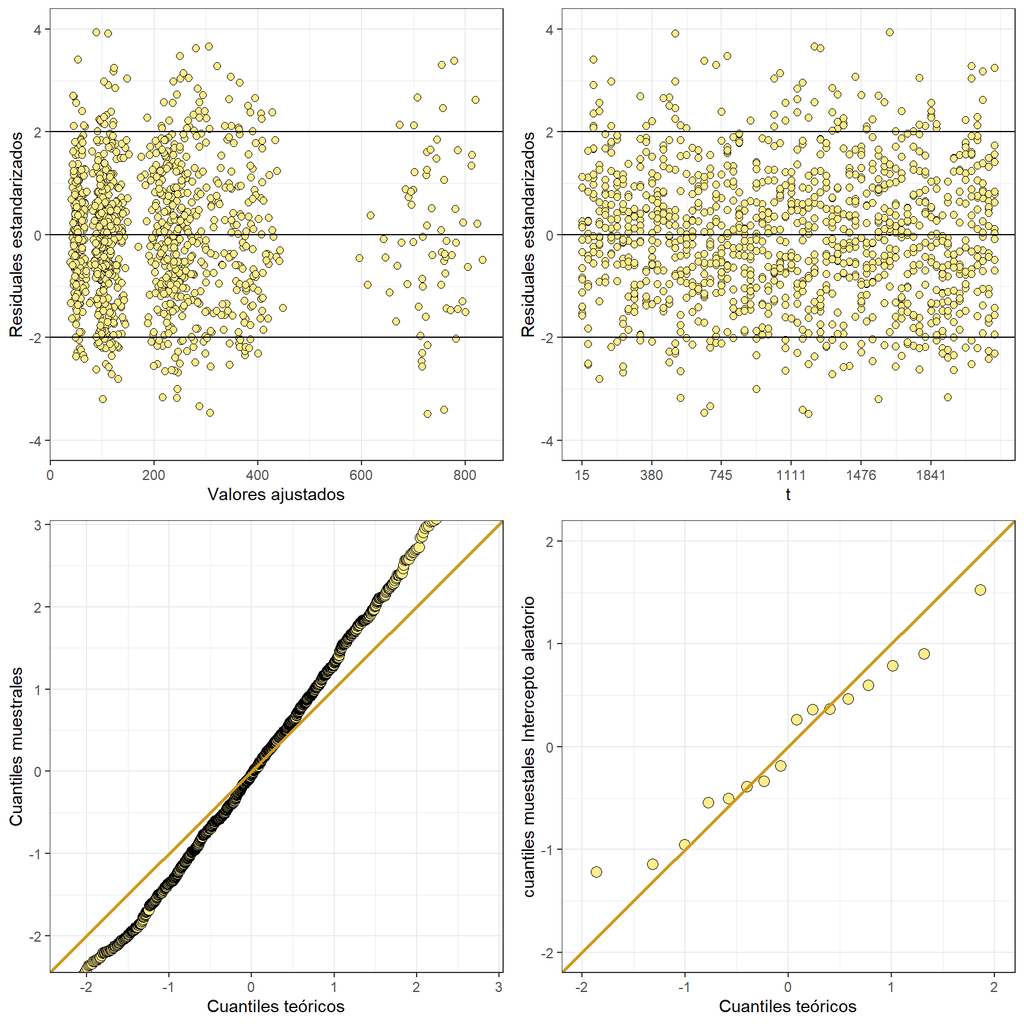

### Expresión del modelo

$$\log (\widehat{\lambda_{ij}}) = 4.9180 -0.1385t + 0.0906t^2 + 0.6405t^3+ 0.9706 t^4 +0.1074MES_{Febrero}+\\0.1680MES_{marzo}+0.1287MES_{Abril}+0.1924MES_{Mayo}+0.1126MES_{Junio}+\\ 0.1855MES_{Julio}+0.2369MES_{Agosto}+ 0.2147MES_{Septiembre}+ 0.2028MES_{Octubre}+\\0.1274MES_{Noviembre}+0.1641MES_{Diciembre} + b_{0j}$$

Los valores estimados de $b_{0j}$ se muestran a continuación:

| j | Comuna | b0 |
| --- | --- | --- |
| 1 | Aranjuez | 0.2636229 |
| 2 | Belén | 0.3671174 |
| 3 | Buenos Aires | -0.1857351 |
| 4 | Castilla | 0.7903509 |
| 5 | Doce de Octubre | -0.5037175 |
| 6 | El Poblado | 0.5952949 |
| 7 | Guayabal | 0.4664752 |
| 8 | La América | -0.3332942 |
| 9 | La Candelaria | 1.5235809 |
| 10 | Laureles Estadio | 0.9030769 |
| 11 | Manrique | -0.3896728 |
| 12 | Popular | -1.1441775 |
| 13 | Robledo | 0.3636193 |
| 14 | San Javier | -0.9528285 |
| 15 | Santa Cruz | -1.2203906 |
| 16 | Villa Hermosa | -0.5422732 |

Y con $\widehat{\sigma^2_{b0}} = 0.5765$

### Modelo Ajustado

A continuación se muestra el modelo ajustado sobre los datos reales para cada una de las 16 comunas de área metropolitana:

[output not shown]

#### Aranjuez

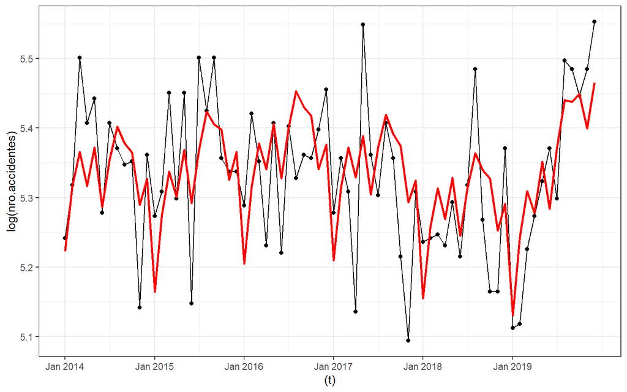

#### Belén

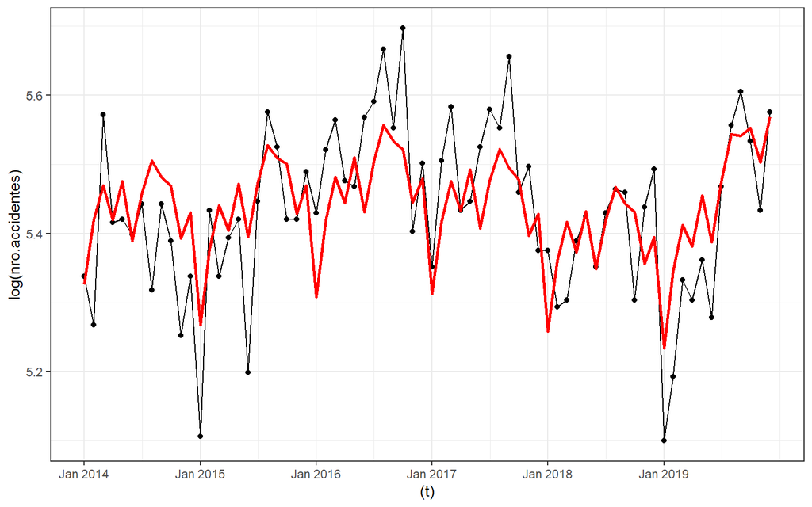

#### Buenos Aires

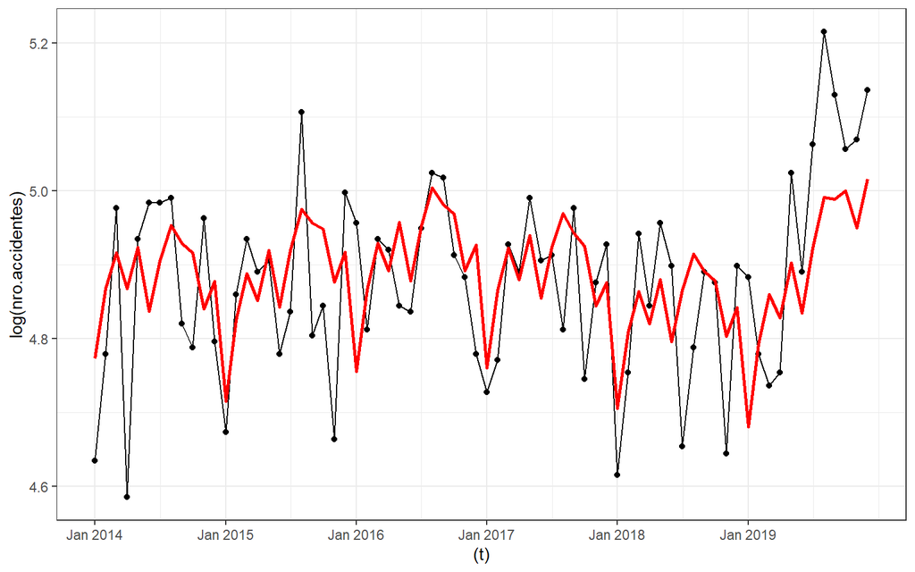

#### Castilla

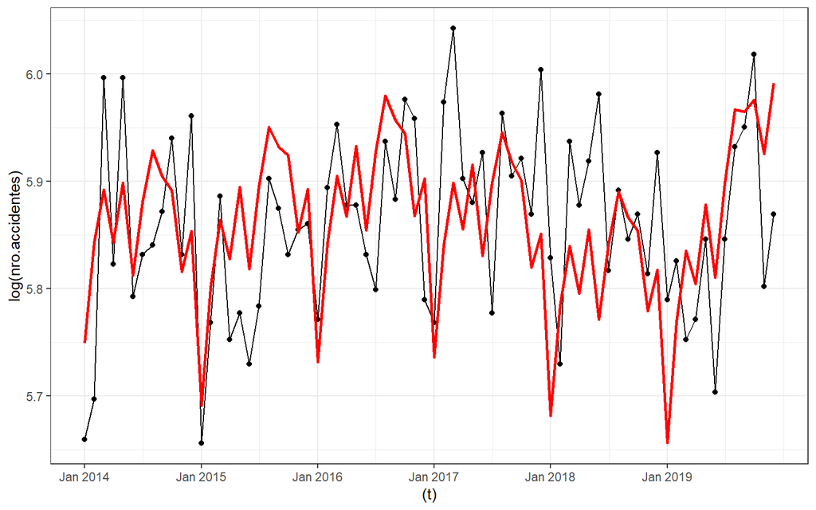

#### Doce de Octubre

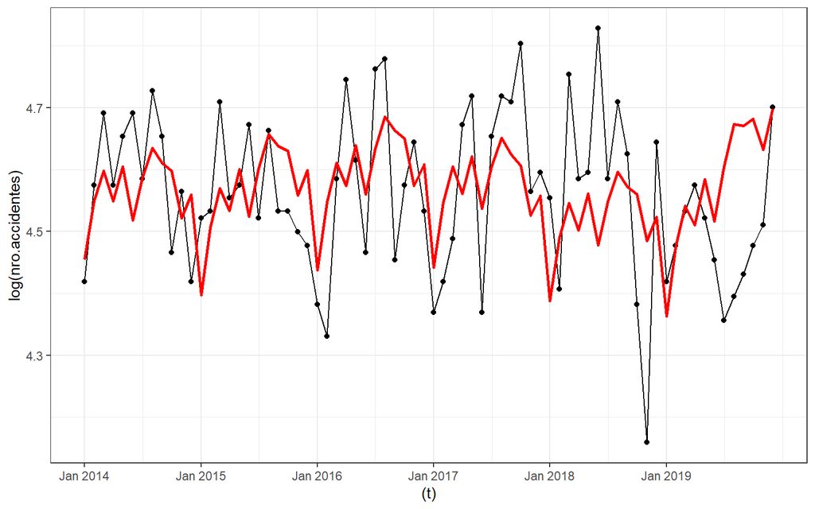

#### El Poblado

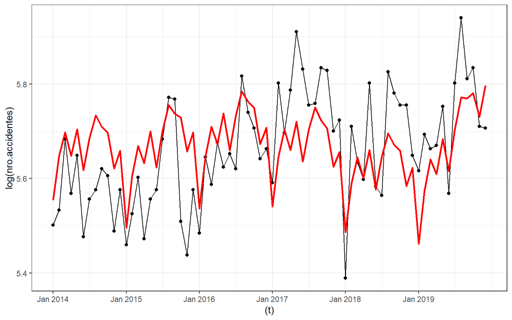

#### Guayabal

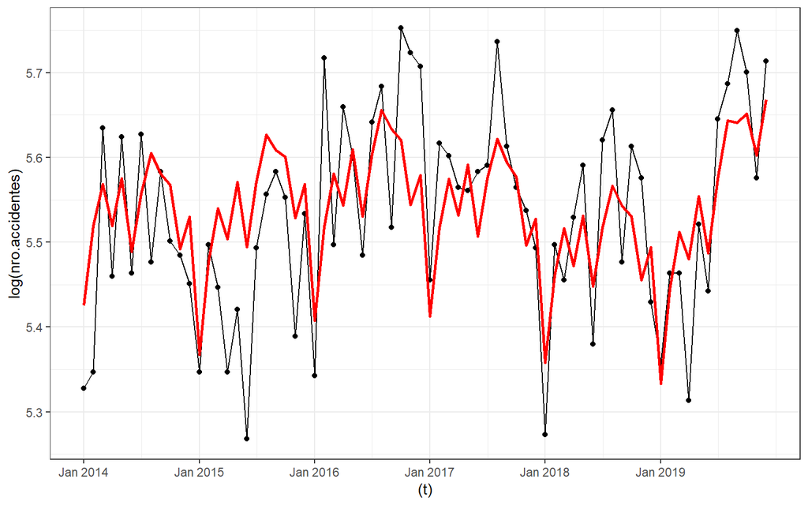

#### La América

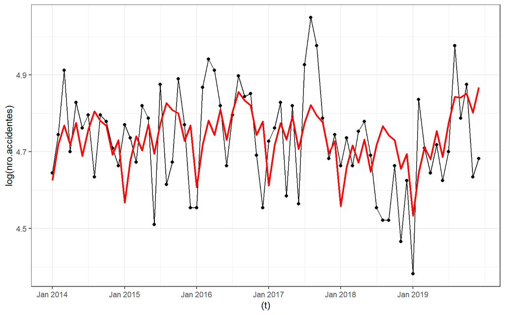

#### La Candelaria

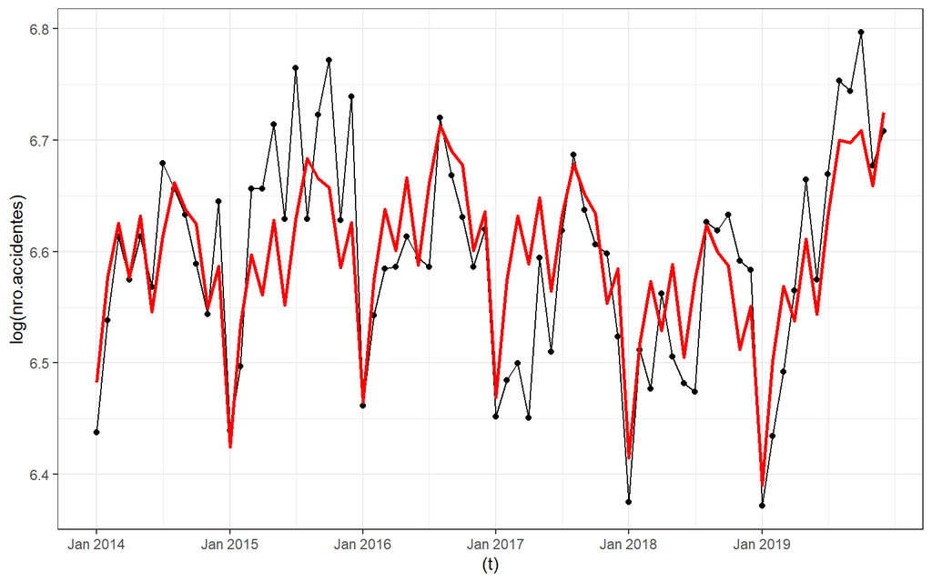

#### Laureles Estadio

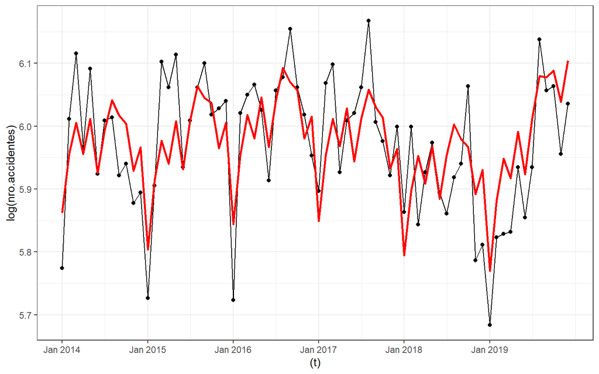

#### Manrique

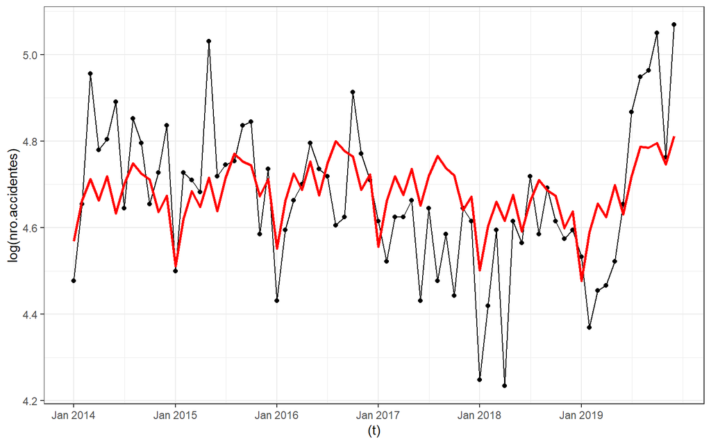

#### Popular

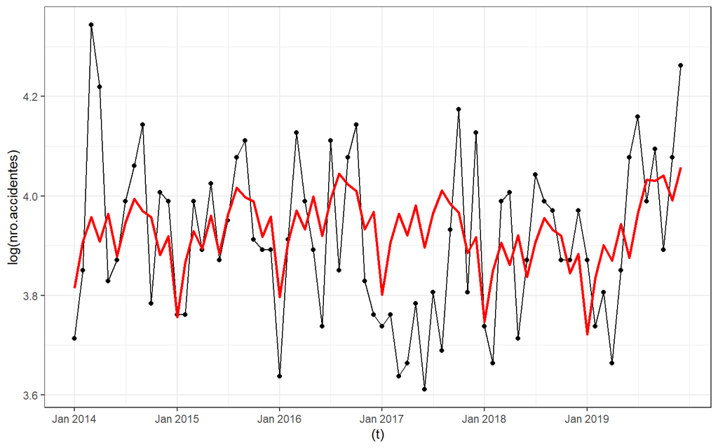

#### Robledo

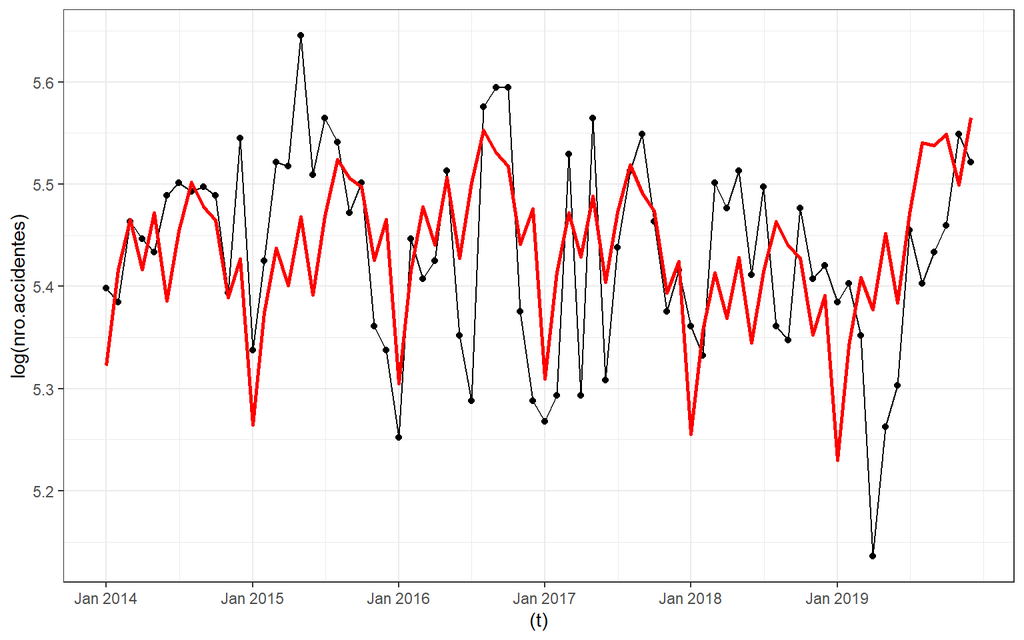

#### San Javier

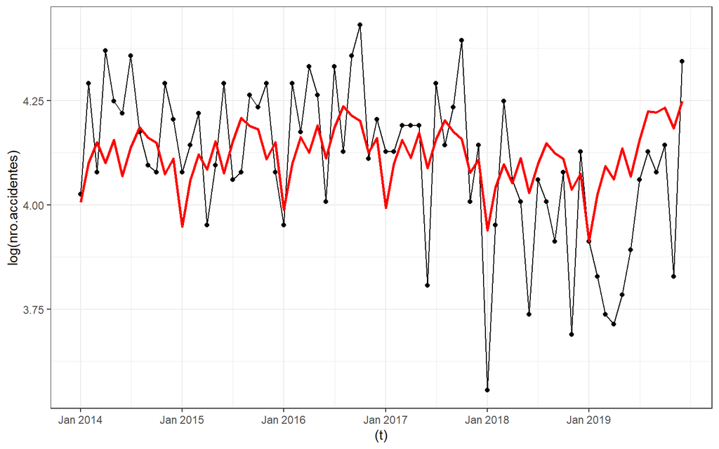

#### Santa Cruz

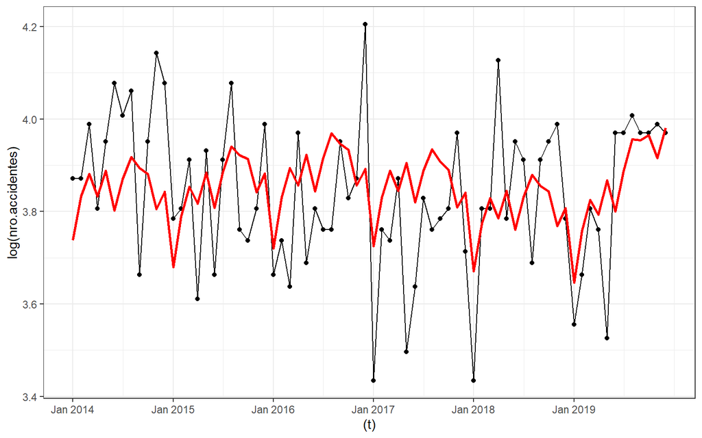

#### Villa Hermosa

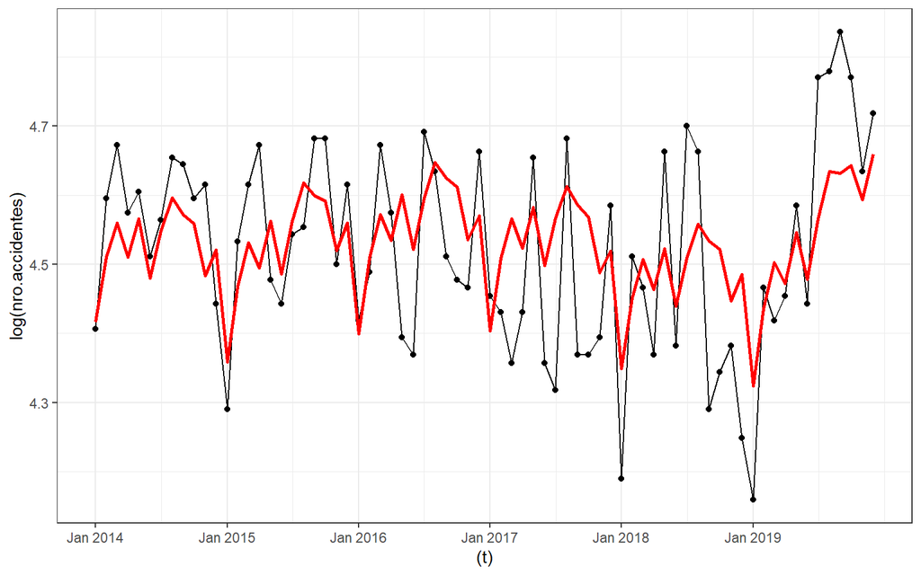

## Modelo con respuesta Multinomial

Para modelar la cantidad de accidentes según la clase consideraremos una regresión con respuesta multinomial (Diferente a la regresión logística Multinomial usada para clasificación). Sean:

$$o = Atropello,\;\; p = Caida.Ocupante,\;\; q = Choque,\;\; r = Volcamiento,\;\; s = Otro \\ j: Comuna\; (1:16) \\ i: observación\; correspondiente\; a\; un\;mes \; entre \; 2014 \; y \; 2019 \; (1:72)$$

Ell vector de Accidentalidad $y_{i,j}$:

$$y_{i,j} = (y_{i,j}^o, y_{i,j}^p, y_{i,j}^q, y_{i,j}^r, y_{i,j}^s)$$

Con un total de accidentes (nro.accidentes) dado por:
$$n_{ij} = y_{i,j}^o + y_{i,j}^p + y_{i,j}^q + y_{i,j}^r + y_{i,j}^s$$

Y $\theta_{ij}$ el vector de probabilidad según la clase del accidente.

$$\theta_{ij} = (\theta_{ij}^o, \theta_{ij}^p,\theta_{ij}^q, \theta_{ij}^r, \theta_{ij}^s)$$

Para ajustar nuestro modelo consideraremos que:

$$y_{ij}|\theta_{ij} \sim Multinomial(n_{ij}, \theta_{ij})$$

$$\theta_i = Softmax(0, \mu_j^p,\mu_j^q, \mu_j^r, \mu_j^s)$$

Entonces, nuestro objetivo es modelar $\mu_j^p,\mu_j^q, \mu_j^r, \mu_j^s$ incluyendo covariables

### Ajuste de modelos

Se consideran polinomios de grado 3 y superior para el modelamiento

#### Modelo 1:

$$\mu_j^p = \beta_0^p + \beta_1^p t + \beta_2^pt^2 + \beta^p_3 t^3 + b^p_{0j}$$
$$\mu_j^q = \beta_0^q + \beta_1^q t + \beta_2^qt^2 + \beta^q_3 t^3 + b^q_{0j}$$
$$\mu_j^r = \beta_0^r + \beta_1^r t + \beta_2^rt^2 + \beta^r_3 t^3 + b^r_{0j}$$
$$\mu_j^s = \beta_0^s + \beta_1^s t + \beta_2^st^2 + \beta^s_3 t^3 + b^s_{0j}$$

### Evaluación de residuales